# Sustaining innovation during downsizing strategy through knowledge coupling, business process digitization, and market capitalizing agility

[figure not shown]

https://doi.org/10.1177/03128962221142435

*Australian Journal of Management*

**Sustaining innovation during downsizing strategy through knowledge coupling, business process digitization, and market capitalizing agility**

**Sayed Muhammad Fawad Sharif Naiding Yang** School of Management, Northwestern Polytechnical University, Xi’an, P.R. China

#### **Atiq ur Rehman** NayaKam, Pakistan

#### **Omar Alghamdi** Business Administration Department, Applied College of Najran University, Najran, Saudi Arabia

**Abstract** COVID-19 has developed chaos and uncertainty for small and medium enterprises (SMEs) causing mass downsizing. Under such uncertainty, innovation is key to survival and agility to growth. This study examines role of knowledge coupling and business process digitization (BPD) in sustaining innovation through market capitalizing agility (MCA) besides downsizing strategy. Data have been collected from top and mid management of Chinese manufacturing SMEs and analyzed with knowledge-based view and self-tuning model through Smart-PLS 4. Knowledge coupling positively contributes to MCA and innovation irrespective of downsizing strategy. Effect of BPD on innovation performance is same; however, insignificant on MCA in no-downsizing sample. Likewise, MCA positively influences innovation performance and positively mediates between knowledge coupling (BPD) and innovation performance only during downsizing. This study is first of its kind to establish mediating effect of MCA between knowledge coupling (BPD) and innovation performance during downsizing phase and offers significant theoretical and practical implications.

**JEL Classification:** J63, O31

**Corresponding author:** Naiding Yang, School of Management, Northwestern Polytechnical University, Dongxiang Road, Chang’an District, Xi’an Shaanxi, 710129, P.R. China. Email: naidingy@nwpu.edu.cn

Final transcript accepted on 9 November 2022 by Sam Kirshner (AE Information Systems and Operations Management)

*Article*

**Keywords** Business process digitization, downsizing, innovation performance, knowledge coupling, market capitalizing agility, SME

#### **1. Introduction**

COVID-19 pandemic has been around for an extended duration causing uncertainty and survival challenges for small and medium enterprises (SMEs) (Kumar and Ayedee, 2021). The slowdown in economic activities and shrinkage in productions and sales have pushed enterprises to layoff workforce enormously; such managerial practices influence SMEs innovation capabilities and likelihood to adapt to new reality. International labor organization has estimated a decrease of 250 million individuals in the labor force due to COVID-19 pandemic (ILO, 2021). Knowledgeable human resource is critical for SMEs to evade the adverse effects of the pandemic (Charoensukmongkol, 2021). Observed perseverance of innovation is central to SMEs’ survival (Chen et al., 2020; Jiao et al., 2020); likewise, prominence of agility is no more in concealment and recognized in changing environments (Cegarra-Navarro et al., 2016; Dabic et al., 2021). SMEs are resource constrained and retention of human resource would limit their ability to meet operational expenses; therefore, SMEs are in a state of paradox. Restructuring compromises their ability to innovate and not restructuring challenges their ability to cover operational costs (Ramdani et al., 2021). This study aims to empirically develop a valuable strategy where Chinese manufacturing SMEs can sustain innovations and agility alongside downsizing strategy.

After thorough review of literature, we identified following important research gaps. First, previous scholars have largely investigated static knowledge management practices in pursuit of innovations, breadth (Mei et al., 2021), sharing (Ritala et al., 2015), and integration (Wyrtki et al., 2021). With downsizing organizational routines change, which calls for more dynamism in knowledge management practices. Knowledge coupling is a result of dynamic interactions among different knowledge domains and contribute to firm innovation performance (Yayavaram and Chen, 2015); though, empirical evidence is rare with respect to downsizing. Second, business process digitization (BPD) is the transition from manual to digital means of running business functions and is gaining attention of scholars as potential antecedent of innovation (BarNir et al., 2003; Zhou et al., 2018); however, the mechanism is also understudied in relation to downsizing. BPD is a multifaceted phenomenon that impacts SME at different echelons (Broekhuizen et al., 2021). BPD avails timely information during chaotic and uncertain times that can potentially streamline business processes and redefine strategies (Ali et al., 2022). Alignment between firm’s knowledge management practices and digitized business processes could be synergetic to SME innovation performance alongside layoffs. However, little is known about this thesis.

By virtue of small size and lesser investments, SMEs are at advantage to reinvent themselves. Self-tuning model suggests SMEs to reexamine internal capabilities in reference to external changes and adapt to the new environment to gain competitiveness (Del Giudice et al., 2021; Rico et al., 2020). SME agility is a high order dynamic capability that rests upon low order capabilities (Grant, 1996) and is the ability to sense market changes and effectively respond through adaptation, hence enabling SME to become flexible (Al-Omoush et al., 2020; Del Giudice et al., 2021). SME achieves agility either from demand side—operational adjustment agility (OAA), or with knowledge management and innovation orientation—market capitalizing agility (MCA) (Lu and Ramamurthy, 2011). Ritter-Hayashi et al. (2020) argued that flexibility is critical for evading adverse effects of downsizing on SME innovation performance in developing economies.

COVID-19 has resulted in chaotic and dynamic environment causing mass downsizing or pushing survivors into isolation (Papadopoulos et al., 2020). In such environment, knowledge coupling creates more knowledge and skills to compensate for layoffs and BPD connects workers remotely; therefore, digitization and effective knowledge management practices can develop MCA during pandemic (Lee et al., 2015). In product innovation literature, knowledge coupling and BPD have been least related to MCA development with respect to downsizing strategy. We postulate that mediating role of MCA will sustain SME innovation performance during downsizing phase but requires empirical evidence.

To fill the aforementioned research gaps, this study integrates knowledge-based view (KBV) with self-tuning model. KBV regards knowledge elements critical for problem-solving and posits knowledge recombination as a source of agile behavior and innovation (Al-Omoush et al., 2020; Jin et al., 2022). Similarly, self-tuning model underscores digitization and agility to overcome market uncertainty (Del Giudice et al., 2021; Reeves et al., 2015). We expect to answer the following critical questions:

Can knowledge coupling and BPD sustain SME innovation performance irrespective of downsizing strategy?

Does MCA mediate between knowledge coupling (BPD) and SME innovation performance irrespective of downsizing strategy?

While answering these research questions, this study empirically examines a unique conceptual model with two data samples of downsizing and no-downsizing and responds to the calls from Al-Omoush et al. (2020) and Dabic et al. (2021). Results elucidate that in downsizing sample knowledge coupling and BPD positively contribute to SME innovation performance and MCA mediates these relations. In no-downsizing sample, BPD turns insignificant to MCA; likewise, MCA fails to mediate these effects. This study contributes to KBV, self-tuning, digitization, agility, innovation, and strategic management literature.

#### **2. Literature review**

#### *2.1.COVID-19 pandemic and SMEs innovation performance*

Under the influence of COVID-19 pandemic, business environment for SMEs is in extreme turbulence and changes are happening with unprecedented velocity (Kumar and Ayedee, 2021). Today SMEs can no longer enjoy the luxury of evolving strategies rather battling for survival (Lee and Trimi, 2021). The trends of globalization, technological advancements, and alike have already been threatened by the pandemic. China is a well-grown and developed market that increases its resilience and decreases reliance on global trade in terms of the pandemic (Lee and Trimi, 2021); however, SMEs still encounter challenges for survival that drives them to innovate (Disoska et al., 2020; Galanakis et al., 2021). Product Development and Management Association (PDMA, 2004) views innovation as the introduction of new process, product, or service. Enterprises make innovations in terms of management practices, product, or process. The pervasiveness and interaction of activities aiming product development has been integral part of process innovation literature. Knowledge recombination and creation lie at the heart of process innovation (Chen et al., 2020). New organizational structures, management practices, and administrative systems have been part of managerial innovation literature. In this regard, Chandler (1962) stressed synergy between strategy and the structure. Strategy

foresees long-term objectives and opportunities to which structure allocates resources. Similarly, innovation in terms of product is modification or introducing completely new product (good or service).

By virtue of pandemic caused uncertainty, SMEs innovation performance has degraded and need to identify and understand path leading to sustainable SME innovation has arisen. For SMEs, innovation is a reason of survival and growth but SMEs are the ones most affected in terms of drop in innovation performance (Kumar and Ayedee, 2021). While several SMEs in the European region have been hesitant to continue innovation based projects due to uncertainty, Chinese SMEs have invested more to live through hard times (Disoska et al., 2020; Galanakis et al., 2021). To survive and return to normalcy, proper response strategy and management are critical.

#### *2.2. Downsizing*

Downsizing is firm’s intentional engagement in employees’ cutback to elevate organizational efficiency and performance (Kawai, 2015). There is a growing body of knowledge explicating firms’ reasons for executing downsizing strategy. Drew’s (1994) analysis of 44 Canadian enterprises regarded decline in sales, poor responsiveness to customers’ needs, weak financial performance, and competition with multinational firms as reasons for laying-off workforce. In UK-based nonfinancial firms, Hillier et al. (2007) noted plant closer, restructuring, and poor performance as motivations behind downsizing. In Chinese market, the primary reason was challenges to productivity (Dong and Xu, 2008). Available literature has little to comment on the effect of downsizing on firm’s innovation during the pandemic and suggest strategies to erode this adverse effect. Extant literature has addressed downsizing in the context of economic slowdown that is led by recession; whereas, this study focuses on the COVID-19 pandemic. A primary difference in both contexts is the social distancing. In previous economic recessions, workers were encouraged to freely search for alternative economic activities. However, in the current COVID-19 pandemic, workers are encouraged to practice social distancing and stay at home. As the context is different; therefore, strategies applied to erode the effect of downsizing must be different.

For SMEs, innovation is not simply an activity rather a detailed strategy and involvement at top, middle, and functional levels are equally critical (Richtnér and Åhlström, 2006). Senior management is responsible for devising the strategy, mid management allocates resources, whereas, functional managers and the team perform the tasks. Similarly, innovation asks for high degree of creativity and cognitive abilities to solve complex problems (Sloman and Fernbach, 2018). Downsizing at any level would cause disruption in SMEs striving for innovation during contingency (Brauer and Laamanen, 2014; Ramdani et al., 2021). Relevance of human resource in SMEs has been already established to prevent negative influence of COVID-19 pandemic (Charoensukmongkol, 2021; Charoensukmongkol and Pandey, 2022).

#### *2.3. Knowledge coupling*

KBV regards organizational knowledge as a critical source for complex problem-solving and competitiveness. Theory emphasizes on superior coordination among employees to integrate their knowledge and gain better outcomes. How an organization manages its knowledge resources determines its success in terms of innovation and competitiveness (Huang et al., 2022; Miles, 2012). Knowledge is the foundation of innovation; it is critical to continuously integrate knowledge resources both internally and externally, which makes knowledge management a significant means in terms of SME innovation performance (Chen et al., 2020).

Coupling is a phenomenon which refers to the interaction of two or more systems (Yayavaram and Ahuja, 1994). Knowledge coupling is the result of integrating knowledge elements of different domains through continuous and dynamic combinations (Huang et al., 2022). Knowledge coupling mirrors firm’s anticipated useful recombination of knowledge elements (Chen et al., 2020). Yayavaram and Chen (2015) regarded it as the degree a firm would recombine elements of dissimilar knowledge domains with the tenacity of inventions. This study considers knowledge coupling as the extent to which a firm and its partner can combine knowledge elements (Chen et al., 2020). Through recombination, SME responds to new challenges as well as enlarges its knowledge base (Chen et al., 2020). SME’s knowledge base is composed of knowledge elements belonging to different knowledge domains and the relationships between these domains (Grant, 1996). The kind of relationship being investigated in the current study is coupling; high potency of coupling reflects recombining elements from X and Y different domains rather than X or Y single domains (Yayavaram and Ahuja, 1994). Technological advancement is a function of knowledge coupling, which could be new—recombining knowledge elements that were not coupled before, or change in existing—exiting existing combination and forming new ones (Yayavaram and Chen, 2015). Firms’ knowledge bases could appear largely similar but their potential recombination may vary. Couplings are the function of match and interconnectedness between the to-be-combined knowledge domains; therefore, SMEs opt for collaboration and co-optative ventures (Chen et al., 2020). Since these interconnectedness are hard to understand completely; therefore, outcome could not be ensured and may be strong couplings (always coupled), weak couplings (rarely coupled), or no couplings (independent elements) (Yayavaram and Chen, 2015). In response to downsizing caused by COVID-19 pandemic, SMEs are highly relying on knowledge recombination and the ones failing may fail to survive (Klein and Todesco, 2021). Therefore, special emphasis is needed to investigate the dynamic knowledge management in SMEs and better equip them on challenges relating to knowledge creation, usage, and response with respect to the pandemic to elevate adoptability to new reality (Klein and Todesco, 2021). Few works have considered the dynamic perspective of knowledge management—knowledge coupling and recombination, in relation to innovation performance (Huang et al., 2022; Jin et al., 2022; Yayavaram and Chen, 2015) but none in relation to pandemic caused downsizing.

#### *2.4. Self-tuning model*

Self-tuning model emphasizes the application of digital resources to develop agile practices and transform business model in accordance to external market needs (Reeves et al., 2015). The strategy has gained acceptance in online businesses to readjust internal processes through experimentation (Reeves et al., 2015); likewise, innovation management has also relied on its two principles of agility and digitization (Del Giudice et al., 2021). Market dynamism demands dynamism in managerial practices to overcome uncertainty and ease internal operation (Reeves et al., 2015). It’s no surprise that management constantly highlight the need for “re-tuning,” which has never been an easy task. Self-tuning allows SMEs to pass through dynamic environment and achieve new stability through digitization and agility (Del Giudice et al., 2021; Reeves et al., 2015). In subsequent lines, we try to understand how BPD and MCA help SMEs to retune their operations and sustain innovation performance alongside downsizing strategy.

*2.4.1. Business Process Digitization.* In wake of the pandemic and uncertainty, BPD is the most critical force behind agility and innovation (Al-Omoush et al., 2020; Lee and Trimi, 2021). Transition from physical outlets to online stores, mega billboards to live-streaming, and ridesharing were least

imagined until recently. In the pretext of agility and innovation, BPD is viewed as external enabler to foster business processes (Lee and Berente, 2012). Therefore, BPD is the transition of performing business processes from manual to digital means (BarNir et al., 2003). This transition is parallel to Slywotzky et al. (2000) ideation of digitization, “a disruptive, creative force that is revolutionizing how people work, play, communicate, buy, sell, and live.” In this debate Internet is at the heart of forth industrial revolution in SMEs. Scholars believe that BPD dissolves traditional boundaries and reshapes the understanding of process and managerial innovations (Lee and Berente, 2012), which is why existing theories become somehow obsolete and further investigations of the intersection of these phenomena remains needful. The assumption beneath this transition is that digitization is different from traditional technologies and the shift thereof (Yoo et al., 2010). They have recurrently evolving and generative capacity that can overturn established behaviors (Lee and Berente, 2012).

By virtue of mass downsizing and social distancing, hurdles in routine business operations during the pandemic curtailed SMEs’ innovation performance (Disoska et al., 2020; Galanakis et al., 2021). Papadopoulos et al. (2020) regard digitization instrumental for SMEs to effectively counter adversaries caused by COVID-19. Internet enabled SMEs to automate operations and communicate internally and externally (Ali et al., 2022) while following the COVID-19 protocols of social distancing (Akpan et al., 2020). Therefore, it is essential to examine role of digitization in evading the adverse effect of downsizing and securing innovation performance which has not been studied before during uncertain times such as recent pandemic. In terms of COVID-19, managerial communication is critical to overcome job insecurities (Charoensukmongkol and Suthatorn, 2022) and digital infrastructure eases such communications. Digitization can assume different roles—products (Del Giudice et al., 2021), infrastructure (Zhou et al., 2018), or application—to influence innovation and agility (BarNir et al., 2003). In this study, we examine the role of Internet to facilitate information gathering and market research; sales, marketing, and customer service; administration; and internal and external communications (for details see BarNir et al., 2003).

*2.4.2. Market capitalizing agility.* SMEs must remain flexible, proactive, and adopt to the changes brought by COVID-19 pandemic to stay alive and grow (Al-Omoush et al., 2020; Charoensukmongkol and Pandey, 2022). The intensity of unanticipated external changes defines the depth of two dimensions needed for SME’s agility. First dimension relates to firm’s internal capabilities; that is subdivided in to various strengths to respond to the total change individually—OAA (Lu and Ramamurthy, 2011). Thus, SME must divide the change across various achievable goals to transform itself. Second dimension focuses on external changes; ability to detect and respond—MCA (Lu and Ramamurthy, 2011). Dove (2001) regarded responsiveness as ability to take practical actions in view of sensing capability. MCA “emphasizes a dynamic, aggressively change-embracing, and growth-oriented entrepreneurial mind set about strategic direction, decision making, and judgment in uncertain condition” (Sambamurthy et al., 2003). Yusuf et al. (1999) regarded agility as a holistic strategy that is success of competitive strategies including flexibility, proactivity, speed, and innovations which enable it to thrive in unanticipated market changes. Since pandemic has altered external market, SME must correspond to the change accordingly; therefore, current study focuses on MCA. Besides, MCA has relatively stronger orientation toward innovation and entrepreneurial mind-set (Lu and Ramamurthy, 2011). Where OAA centers in SMEs internal operations and deals with demand change, MCA emphasizes knowledge and intellectual ability to process volumes of information and improve product offerings (Lu and Ramamurthy, 2011).

In the innovation management literature, MCA avoids harms while sensing market changes and responding innovatively because of firm’s knowledge of the market and deep awareness of the trends (Roberts and Grover, 2012). Pro-activeness is forward looking and pervasiveness of uncertainty in business world pushes SMEs to opt agile behavior, which has been regarded as a

testimony of survival through such uncertain events (Al-Omoush et al., 2020; Roberts and Grover, 2012). SMEs primary strategy during the pandemic has been to adopt to the prevailing needs and become resilient (Klein and Todesco, 2021). Therefore, it would be worthy to empirically examine such role played by MCA in evading harms caused by downsizing during a pandemic situation. SMEs being small have been at advantage to reinvent themselves during COVID-19 pandemic (Al-Omoush et al., 2020). Scholars regard MCA as firm’s critical ability to adopt itself to the environment (Reeves et al., 2015) but its value in chaotic situation like pandemic has largely gone unnoticed, specifically evading adverse effect of downsizing.

#### *2.5. Hypotheses development*

*2.5.1. Influence of knowledge coupling on MCA and innovation performance.* Agile practices are essential for organizations trying to align production factors with changing external conditions to satisfy stockholders’ expectations, especially during crisis like COVID-19 (Al-Omoush et al., 2020). To address this challenge, organizations need to update their knowledge-based skills and make them even with changing market and environment in particular (Cegarra-Navarro et al., 2016). Dynamic knowledge management practices, specifically, are seen as sources of pro-activeness and flexibility to avail agile practices during the pandemic (Al-Omoush et al., 2020; Huang et al., 2022). So much knowledge comes from observation and evaluation of external experiences, expertise, and processes; firm needs to translate this knowledge into beneficial explicit actions (Huang et al., 2022). Therefore, MCA is the product of recombination of such knowledge elements into new coupled skills. Extent literature argues that integrating knowledge domains do establish agile behavior to scan market changes (Cegarra-Navarro et al., 2016). Under such understanding, MCA is organization’s ability to exploit knowledge structure and compete uncertainty during the pandemic successfully (Al-Omoush et al., 2020). Literature suggests that SMEs must intensify collaborative knowledge recombination to generate new business solutions in accordance to the prevailing pandemic (Al-Omoush et al., 2020; Huang et al., 2022).

Jin et al. (2022) concluded that knowledge-centered practices enable workers to exploit existing processes and explore better skills that result in innovative products. Earlier empirical examinations from static KM perspective report a positive role of knowledge management practices on firm innovation performance. Organizations continue to explore, exploit, and learn new knowledge combination—dynamic KM perspective; however, little understanding is available regarding its influence on firm innovation performance (Chen et al., 2020; Huang et al., 2022), specifically when firm is practicing downsizing strategy. Aiming innovations, SMEs continue to break existing knowledge combinations and recombine them to form new couplings (Yayavaram and Chen, 2015). Breaking existing knowledge structures allow SME to deeply understand the interconnectedness and may result in incremental and exploitative innovations (Chen et al., 2020). Firms take advantage of exploitation to improve processes; likewise, firms recombine knowledge elements and produce new couplings that could result in developing novel products (Martínez-Costa et al., 2019). This destruction and reconstruction of knowledge structures bring novel solutions to complex problems (Yayavaram and Chen, 2015).

In terms of downsizing, SME’s abilities to remain flexible in manufacturing and innovative in its processes are retained in developing economies due to workers’ willingness to accept additional training and cognitive labor (Brauer and Laamanen, 2014; Charoensukmongkol and Pandey, 2022; Ritter-Hayashi et al., 2020). Training has significant influence on the outcomes of knowledge recombination and creation in a dynamic market in terms of MCA and innovation (Jin et al., 2022). SMEs in developing countries are resource-short and relay on process redesign to gain efficiencies and low cost solutions (Ritter-Hayashi et al., 2020)—a process regarded as frugal innovation (Jain,

2020). Frugal innovation or process redesign is the antecedent of flexible manufacturing and SME’s responsiveness to the external changes (Jain, 2020). Besides, knowledge recombination is continuous effort for frugal innovation and compensate for the lost knowledge to remain responsive to external changes in the form of innovative products (Suchard and Shinkle, 2019), therefore, evading the potential adverse effect of layoffs. As per KBV, knowledge elements cause relearning that influence organizational outcomes in the shape of MCA and innovation (Jin et al., 2022). Downsizing cuts human resource that pushes survivors to perform knowledge recombination and elevate SME’s MCA and innovation. SMEs are small in size and flexibility is achieved relatively easy. As downsizing significantly changes organizational routines; therefore, we expect knowledge coupling (dynamic perspective) could contribute to SME innovation performance with and without downsizing strategy alike. Relearning in the shape of new skills leverage internal business processes and develops responsiveness toward volatility and market dynamism such that downsizing does not influence the relationship between knowledge coupling and SME’s MCA (innovation performance):

*Hypothesis 1 (H1).* Irrespective of downsizing, the effect of knowledge coupling on SME MCA is positively significant.

*Hypothesis 2 (H2).* Irrespective of downsizing, the effect of knowledge coupling on SME innovation performance is positively significant.

*2.5.2. Influence of BPD on MCA and innovation performance.* Contemporary firms widely rely upon digital resources to communicate with customers and cope with changing customer preferences, thereby enhancing MCA and innovations (Del Giudice et al., 2021; Zhou et al., 2018). The pandemic has put SMEs and workforce in a state of lockdown that further highlights the pervasiveness of Internet-based digital infrastructure (Klein and Todesco, 2021). Digitization engineers flexibility in SME to handle unstructured and unanticipated external changes (Overby et al., 2006). In this regard synergy between digital infrastructure and business operations is highly recommended (Zhou et al., 2018). A good fit can seamlessly integrate and automate routine operations, for instance, internal and external communication in accordance with customer, supplier, logistics, and other stakeholders’ expectations to ease operations. Certain characteristics of SMEs (limitations in managerial capabilities—procedures, tools, and techniques; limitation in capital and human resource management) restrain them to effectively cope with a crisis situation, which invite them to opt digital infrastructure in order to adopt to the changed market conditions during the pandemic (Klein and Todesco, 2021). BPD allows firms to collect timely information and reconfigure processes to respond to external pressures in a more agile fashion (Lu and Ramamurthy, 2011). BPD has helped enterprises to develop global value chain with connectivity, responsiveness, resilience, and agility during the recent pandemic (Lee and Trimi, 2021). Effective applications of digital resources bring efficiency in business processes; it allows SMEs to capture accurate knowledge of the changing market conditions and varying customer preferences (Lee et al., 2015); hence, enabling the firm to restructure internal operations (Ritter-Hayashi et al., 2020).

Similarly, BPD has an affirmative effect on innovation under extreme uncertainty (Del Giudice et al., 2021). Digitization fundamentally reinvents a way of doing things and converges ideas to cocreate and achieve shared objectives (Lee and Trimi, 2021). The convergence of ideas is especially relevant to exploit existing processes and discover new ways of doing (Lee et al., 2015). Organizations use Internet as a communication tool that connects and integrates distant units to avail process and managerial innovation (BarNir et al., 2003). During downsizing phase, the disruption in organizational routines and information acquisition is reimbursed through Internet-based digital operations (Klein and Todesco, 2021). Ritter-Hayashi et al. (2020) concluded that equipping

workforce with relevant training and information will detour the adverse effects of downsizing on SME flexibility and process innovation. Therefore, we assume digitization upholds SME’s MCA and innovation performance during COVID-19 enforced downsizing. Sustainable innovation is imperative for growth and survival specifically in turbulent environment such as current COVID-19 pandemic and digital resources are the right choices to ensure (Lee and Trimi, 2021). Literature on self-tuning model advises SME to reinvent itself through reshaping internal processes in accordance to external need and respond effectively to uncertainties and gain competitiveness (Del Giudice et al., 2021; Reeves et al., 2015). Carrying forward self-tuning theorem, we assume that digitization allows SME to reach out timely information; supports internal adjustments to become agile; and responds with more innovative solutions without being influenced by downsizing strategy:

*Hypothesis 3 (H3).* Irrespective of downsizing, the effect of BPD on SME MCA is positively significant.

*Hypothesis 4 (H4).* Irrespective of downsizing, the effect of BPD on SME innovation performance is positively significant.

*2.5.3. Mediating role of MCA between knowledge coupling (BPD) and innovation performance.* The recent pandemic has challenged routines that must change and avail novel practices to ensure survival and growth. Firms must develop agile dynamic capabilities based on flexibility and speed to pass through uncertain competitive environment (Al-Omoush et al., 2020). Organizational agility has been found to be a significant antecedent of innovation performance; however, agility must be reflected in processes as well as intellect (Dabic et al., 2021). MCA centers on creating new value by aligning resources with strategies, thereby designs an appropriate environment so that staff could work out the challenges and come-up with innovative managerial practices (Dabic et al., 2021). During downsizing, agile SMEs are quick to reconfigure resources with respect to the external environment (Ritter-Hayashi et al., 2020). Layoffs result in drastic changes in organizational routines and flexibility is expected to cover for intended innovation performance (Brauer and Laamanen, 2014; Ritter-Hayashi et al., 2020). In a way, layoffs push SMEs to adopt agile practices of flexibility that will bridge between knowledge coupling (BPD) and innovation performance. To achieve this goal, we integrate KBV (knowledge coupling) with self-tuning principles (BPD and MCA) to develop capability of re-tuning and sustaining innovation performance alongside downsizing strategy. Through dynamic capabilities such as sensing and seizing, agile SMEs identify or even generate opportunities (Lu and Ramamurthy, 2011). They are critical for an organization to dismantle existing knowledge structures and recombine again to develop new capabilities (Chen et al., 2020; Yayavaram and Ahuja, 1994; Yayavaram and Chen, 2015). In the age of pandemic caused uncertainty and complexity, agile practices are valuable resources to adapt to the new reality, innovate, and outperform rivalries (Al-Omoush et al., 2020). Integrating KBV with self-tuning, we argue that during downsizing SMEs break existing knowledge combinations to make new couplings and adopt digitization in business processes to uplift MCA, which ultimately upholds innovation performance:

*Hypothesis 5 (H5).* Irrespective of downsizing, the effect of MCA on SME innovation performance is positively significant.

*Hypothesis 6 (H6).* Irrespective of downsizing, MCA positively mediates the effect of knowledge coupling on SME innovation performance.

*Hypothesis 7 (H7).* Irrespective of downsizing, MCA positively mediates the effect of BPD on SME innovation performance.

#### **3. Methodology**

For this study, we take firm as unit of analysis and approach top and mid management for data collection as all study variables are of strategic nature. Top management designs strategy and mid management allocates resources and supervises operations. Besides, SMEs, being small in size, have lesser power distance and both management levels interact frequently that enables them to be fully aware of internal and external changes as well as intended strategies. We collected survey data from Chinese manufacturing SMEs during June–July 2020 for several reasons. First, the pandemic initially appeared in China and a significant portion of workforce was laid off that further elevated uncertainty. Second, China ranks 12th on Global Innovation Index (GII, 2021) and is a prominent global player. Third, Digital Adoption Index (DAI, 2016) suggests that China has open heartedly accepted digitization and connects populous and businesses through Internet. Fourth, SMEs are backbone of any industry where knowledge intensiveness and innovations are relatively at higher degrees. Finally, manufacturing sector recruits the most of Chinese manpower (National Bureau of Statistics of China [NBSC], 2018). We selected Shenzhen, Beijing, and Shanghai for online survey because of their largest share in manufacturing industry.

We asked three industry experts who often teach in academia to translate the English version of questionnaire into Chinese and discuss their translations to reach unanimity and validate the survey. We used cross-sectional survey design for data collection. Spector (2019) argued that crosssectional design is useful for early-stage researches as it achieves four fundamental elements of causal cases: establishes covariation, temporal precedence, rules out alternative explanations for results, and explanatory mechanism. Later, services of a reputed online survey administrator were hired for large-scale survey with screening questions to eliminate sampling errors. The survey administrator maintains a database, regularly updated through industry directory of each city, that helped us inviting 800 random SMEs to participate in the study and 364 submitted their responses. Responses were filtered and 58 were dropped due to identicalness or extreme choices (respondents picked one or seven for whole construct or scale), which produced 306 valid responses for analysis. Tabachnick et al. (2007) suggested maintaining a sample size of more than 10 times number of paths leading to outcome variable for partial least squares structural equation model (PLS-SEM) analysis. Besides, G-power of 80% must be maintained to achieve reliable conclusions (Marcoulides et al., 2009). In this conceptual model, three paths lead to innovation performance and suggested sample size with significance level of 1% and R<sup>2</sup> = 0.25 must be 84 (Hair et al., 2017); therefore, a sample size 306 (38.2% response rate) is suitable for analysis. Our sample (Table 1) is composed of 157 SMEs that downsized workforce due to COVID-19 and 149 did not. Further demographics elucidate that 119 respondents were from top management and 187 mid management; 5 firms had less than 50 employees, 54 between 50 and 100, 44 between 100 and 150, and 203 had up to 250 employees; 49 SMEs were less than 10 years age, 187 between 10 and 20, and 70 more than 20 years; 47 firms were in auto-parts manufacturing, 94 in electronics manufacturing, 89 in tire manufacturing, and 76 in furniture manufacturing; 93 firms were from Shenzhen, 98 from Beijing, and 115 from Shanghai; 33 firms contributed up to 10% of total sales to R&D activities, 79 firms 10%–20%, and 194 firms contributed more than 20%.

#### *3.1. Measures*

We were interested to examine effect of downsizing on study variables during pandemic and not the degree of downsizing. Downsizing is a moderating and categorical variable; respondents marked “Yes” if they downsized workforce due to COVID-19, else “No.” Knowledge coupling is composed of five items (learning and acquiring partner’s (1) skills and experience for production/

service, (2) methods and know-how to solve problems, (3) experience and know-how for customer service, (4) experience and methods for organizational management, (5) practices to overcome our managerial defects) and was adapted from Chen et al. (2020). Digitization has four items (use of Internet for (1) information collection, (2) marketing, (3) administration, (4) internal/external communication) and adapted from BarNir et al. (2003). Three items ((1) decisions appropriate to reference market, (2) reinventing the firm, (3) capitalizing on opportunities) were adapted from Lu and Ramamurthy (2011) to measure market capitalizing agility. Since, operational adjustment agility centers on demand changes and market capitalizing agility focuses on innovativeness in relation to external changes. Therefore, we picked MCA for this study because SME has to continue innovations so that to survive and grow during the crisis. Three items ((1) rapid development, (2) growth, (3) innovativeness) were adapted from García-Morales et al. (2008) to measure innovation performance. Items are shown in Table 2 and 7-point Likert-type scale was used for rating to maintain considerable variability; 1 being extremely disagree and 7 being extremely agree. In addition, SME size, age, location, industry, and R&D expenditure as percentage of total sales dedicated to research and development activities were added as control variables.

#### *3.2. Validity and reliability*

We used PLS-SEM to conduct analysis of measurement and structural models. Smart-PLS 4 has been used as it runs bootstraps, overcomes limitation of normal distribution, and is widely

**Table 1.** Descriptive statistics.

|  | Downsizing | No-Downsizing | Total |
| --- | --- | --- | --- |
| Sizeofthefirm(employees) |  |  |  |
| Lessthan50 | 3 | 2 | 5 |
| 50 100 – | 26 | 28 | 54 |
| 100 150 – | 23 | 21 | 44 |
| Upto250 | 105 | 98 | 203 |
| Ageofthefirm(years) |  |  |  |
| Lessthan10 | 30 | 19 | 49 |
| 10 20 – | 86 | 101 | 187 |
| Morethan20 | 41 | 29 | 70 |
| Industry |  |  |  |
| Auto-parts | 20 | 27 | 47 |
| Electronics | 52 | 42 | 94 |
| Tire | 47 | 42 | 89 |
| Furniture | 38 | 38 | 76 |
| Location |  |  |  |
| Shenzhen | 43 | 50 | 93 |
| Beijing | 59 | 39 | 98 |
| Shanghai | 55 | 60 | 115 |
| R&Dexpenditure |  |  |  |
| Lessthan10% | 16 | 17 | 33 |
| 10% 20% – | 44 | 35 | 79 |
| Morethan20% | 97 | 97 | 194 |

*N* = 306; Downsizing = 157; No-downsizing = 149.

preferred for PLS-SEM analysis (Hair et al., 2019). While measuring convergent validities, first item (skills and experience for production/service) of knowledge coupling and fourth item (internal/external communication) of BPD scored 0.53 on factor loading and overall average variance extracted (AVE) was 0.38 and 0.37, respectively. We ran the model again with 2000 bootstraps excluding these two items as they do not challenge definitions of respective constructs. Table 2 reflects that items’ loading have improved and ranged 0.59–0.87, α = 0.57–0.69, AVE = 0.43–0.62, and composite reliability (CR) = 0.75–0.83. According to Hair et al. (2010), AVE as low as 0.4 is acceptable if corresponding CR is greater than 0.60. Therefore, our model fulfills minimum threshold to establish convergent validity and reliability including knowledge coupling (AVE = 0.43, CR = 0.75) and BPD (AVE = 0.56, CR = 0.79) (Hair et al., 2010).

For discriminant validity, we relied on Fornell and Larcker (1981) criteria. In Table 3, bold values on the diagonal are the square roots of respective AVEs; whereas, values beneath the diagonal are correlations among the constructs. All the bold values are greater than correlations; therefore, discriminant validity is established (Fornell and Larcker, 1981).

We collected single response from each firm at the same time, which could have resulted in common method bias (CMB). Suggestions from Jordan and Troth (2020) and Podsakoff et al. (2003) have been applied to eliminate the threat of CMB. At the survey design stage, respondents

**Table 2.** Convergent validity and reliability.

[output not shown]

VIF: variance inflation factor; CR: composite reliability; AVE: average variance extracted.

were notified through an attached letter that responses carry no weightage; will be strictly used for research purpose; and remain confidential. Besides, items of MCA and innovation were separated; MCA items were kept at the mid and innovation at end of survey. These practices overcome respondents’ bias to match answers of items relating independent and dependent variables and the feeling of being evaluated (Podsakoff et al., 2003). At analysis stage, we examined Harman’s single factor score through exploratory factor analysis and variance inflation factor (VIF); the earlier must explain variance below 50% (Podsakoff et al., 2003) and latter must be less than 3 (Kock, 2015). For this study, Harman’s single factor score was 36% and VIF scores are lower than 1.65 suggesting no potential threat of CMB.

#### *3.3. Structure path analysis*

For categorical variables, Smart-PLS 4 conducts moderation analysis by creating two separate groups. We created two groups; downsizing and no-downsizing and ran analyses. Nature of industry—auto-parts, electronics, tire, and furniture manufacturing—could have different degrees of innovativeness; likewise, location—Shenzhen, Shanghai, and Beijing—may have different cultures and SMEs may score differently on agility; similarly, R&D expenditure, SME size, and age can influence innovation performance. Therefore, these variables were retained as control variables. Table 4 explicate that R&D expenditure is positively significant to SME innovation performance for both samples. Age of SME is positively and size is negatively significant during downsizing; whereas, other control variables are insignificant during and without downsizing.

**Table 3.** Discriminant validity (Fornell and Larcker Criterion).

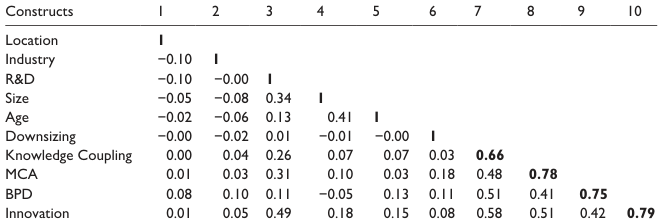

MCA: market capitalizing agility; BPD: business process digitization; AVE: average variance extracted. Bold values on the diagonal are the square roots of AVE while values below the diagonal are correlations between the constructs.

For mediation effect, we examine the total and indirect effects of knowledge coupling and BPD on innovation performance. Table 4 suggests that during downsizing the total effect of knowledge coupling on innovation performance is significant (β = 0.45, *T* = 5.72, p < 0.01) while indirect effect is also significant (β = 0.10, *T* = 2.54, *p* < 0.05). Therefore, the influence of knowledge coupling on SME innovation performance is partially mediated through MCA during downsizing. Furthermore, during downsizing the total effect of BPD on innovation performance is significant (β = 0.20, *T* = 2.83, *p* < 0.01) while indirect effect is also significant (β = 0.06, *T* = 2.08, *p* < 0.05). Therefore, the influence of BPD on SME innovation performance is partially mediated through MCA during downsizing.

For no-downsizing sample, the indirect effects of knowledge coupling (β = 0.05, *T* = 1.76, *p* > 0.05) and BPD (β = 0.01, *T* = 0.90, *p* > 0.05) are insignificant. Therefore, MCA does not mediate these relations in no-downsizing sample.

#### **4. Discussion**

#### *4.1. Theoretical contributions*

The purpose of this study is to ensure sustainable innovation and MCA in Chinese manufacturing SMEs irrespective of downsizing caused by COVID-19 pandemic. Through KBV and self-tuning lenses, we found that knowledge coupling and BPD elevate MCA and innovation performance;

**Table 4.** Results of structural model path coefficients (direct and indirect effects).

[output not shown]

2000 Bootstraps, BPD = Business Process Digitization.

likewise, MCA is positively significant to innovation performance in the presence of downsizing strategy. For no-downsizing sample, knowledge coupling is significant to MCA and innovation performance; whereas, BPD is only significant to innovation performance but insignificant to MCA and MCA is insignificant to innovation performance. MCA partially mediates the effects of knowledge coupling and BPD on innovation performance in downsizing sample but fails to replicate in no-downsizing sample.

Static knowledge management practices, such as knowledge sharing and integration, develop MCA and innovation. However, in spite of shared wisdom that knowledge coupling (dynamic knowledge management practice) develops dynamic capabilities. Both streams of strategic management literature, knowledge coupling and MCA, have grown independent of each other. This study finds that knowledge coupling elevates SME’s MCA and innovations during and without downsizing which fills this gap. Distinctive approaches and solutions enable SME to be responsive, proactive, and competitive. Recombination of skills and processes ease managerial readjustments with reference to external changes (Gibson and Birkinshaw, 2004). These findings confirm that knowledge coupling is a source of collective intelligence to sense and capitalize opportunities in imperfect conditions. Previous investigations, such as Swink et al. (2007), discourage the idea of integrating knowledge and skills from outside the organization; however, our results doubt this notion empirically establishes that recombining knowledge and skills with external partner develops MCA. Similarly, breaking existing knowledge infrastructure allows SME to understand interconnectedness and recombine them in new fashion that elevates innovation performance. This study carries forward the findings of Yayavaram and Chen (2015), Chen et al. (2020) and Al-Omoush et al. (2020) through examining the role of downsizing caused by pandemic. Static knowledge management practice (collaborative knowledge creation) has been found to report similar results in response to COVID-19 pandemic. This study highlights the value of knowledge coupling, which is moderated through downsizing strategy. During downsizing, SME breaks existing knowledge structure which might not be aligned with external change and recombine new couplings to respond to external change in more suitable fashion. Sitlington and Marshall (2011) noted that in post-downsizing phase knowledge loss is a major factor in performance downfall. To preserve performance, SME recombines its knowledge elements to create new knowledge and fill the gap. Similarly, Ritter-Hayashi et al. (2020) concluded that SMEs evade corrosive effect of downsizing from innovations through continuous training and learning. Knowledge coupling is a continuous process of learning that bypasses adverse influence of downsizing and sustains SME’s MCA and innovation performance. Overall, we found that heterogeneous knowledge elements are vital for MCA and innovation performance that supports the idea of recombining knowledge from external sources. Therefore, this study extends scope of external knowledge coupling to SME MCA and innovation during downsizing wave, thereby contributes to knowledge and strategic management literature.

Zhou et al. (2018) accredited significance of digital infrastructure for operational alignment in shaping effective response to market turbulence. Proactive organizations watch the changes occurring in the external business environment and application of Internet-based digital infrastructure enables SME to sense and respond to business requests sooner. Early in hand information is instrumental to flexibility; therefore, SMEs in downsizing sample have significantly benefited from BPD to sustain their MCA. Pro-activeness, responsiveness, and flexibility make SME more agile, which are facilitated by BPD (Lee et al., 2015; Zhou et al., 2018). Likewise, digital infrastructure has been previously noted as a critical antecedent of innovation performance in SMEs (BarNir et al., 2003; Lee et al., 2015). This study contributes to literature on current discussion by bringing the case of downsizing caused by COVID-19. Klein and Todesco (2021) hypothesized that digitization may provide a remedy against the problem of downsizing. Our study finds that BPD significantly relates

to SME innovation performance irrespective of downsizing, thereby provides empirical evidence. Whereas, BPD failed to significantly relate to MCA in no-downsizing sample. Potential explanation could be, such SMEs relied on their conventional methods due to no internal change (downsizing) and digitization has not contributed to MCA. Another explanation found in extent literature is the rigid technological and physical artifact of information systems that imped agility (Overby et al., 2006). The overinvestments in process digitization may result in technological traps that restrain flexibility (Grover and Malhotra, 1999). Moreover, agility has been noted to respond inconsistently to digitization overtime (Lu and Ramamurthy, 2011). We found a boundary condition—downsizing; SME’s BPD and MCA are only significant during wave of downsizing, which is an important contribution to the discussion on downsizing, digitization, and agility literature.

Likewise, when SME executes downsizing strategy, then MCA positively contributes to innovation performance. Brauer and Laamanen (2014) concluded that downsizing eliminates operational inefficiencies and allowing existing workers to redesign their work in a more flexible way. Agile organizations are proactive, sense changes early, and develop an accurate response through innovating novel products and services (Dabic et al., 2021). Ritter-Hayashi et al. (2020) argued that during downsizing SMEs behave more flexibly and sustain innovation which is usually threatened by downsizing. Layoffs push survivors to accept additional cognitive labor and regain their routine through MCA. Therefore, these empirical findings add value to the contributions of Ritter-Hayashi et al. (2020) and Brauer and Laamanen (2014). These results are also in accordance with Al-Omoush et al. (2020) who concluded that in e-businesses, effective applications of knowledge-based resources develop agility through which the organizations respond with innovative solutions to COVID-19. This study also contributes to capability development literature, which argues that higher order capabilities are the outcome of lower order capabilities (Grant, 1996). Knowledge coupling and BPD establish MCA, which supports innovation during COVID- 19 pushed downsizing. Discussion on knowledge coupling and innovation performance in Chinese manufacturing sector has identified some pertinent factors such as organizational memory, knowledge creation (Chen et al., 2020), and managerial capability (Duan et al., 2022) as mediators and mimetic pressure and environmental identity as moderators (Huang et al., 2022). Similarly, Pigola and Da Costa (2022) noted learning to mediate between knowledge management and innovation through a meta-analysis. Wang and Libaers (2016) reported diminishing utility between recombining existing knowledge and innovation output arguing that firms in developing economies don’t have skills and advanced technology, thereby suggesting external new knowledge. This study extends the discussion claiming that recombining knowledge with external sources will develop MCA which mediates between knowledge coupling and SME innovation performance, specifically, during crisis situation.

In no-downsizing sample as stated earlier, internal environment does not change and MCA is not availed, thereby MCA failed to connect BPD with SME innovation performance. However, for downsizing sample layoffs push SMEs to make quick decisions in accordance with reference market and adopt to the change. The primary focus of innovation strategy is to support agility and become competitive during market turbulence. Therefore, this study contributes to agility, innovation, and strategic management literature. Most importantly, this study integrates KBV and selftuning model that focuses on revamping to fit in the new reality through agility and contributes to sustainability literature.

#### *4.2. Practical contributions*

This study also offers suitable recommendations to practitioners in the context of downsizing caused by COVID-19 pandemic. First, managers must conduct external knowledge recombination, which is equally important for MCA and sustaining innovations. During downsizing phase, SME loses

competitive and knowledgeable workforce. Recombining internal knowledge with external sources results in new knowledge and skills that will compensate for such loss. Second, digital resources are useful tools to become responsive and gain MCA as well as innovation. Therefore, SME must align knowledge management and digital infrastructure with larger organizational strategy to survive and grow during downsizing phase. Third, MCA is critical for sustainable innovations in SMEs; therefore, SMEs must adopt to the new environmental changes and reinvent themselves that best suits to the new market. Fourth, direct effect of BPD and mediation of MCA are significant during downsizing phase. Therefore, management must craft contingent configurations; more emphasis must be given to digitization and agility development during a crisis situation.

#### *4.3. Limitations and future research recommendations*

Despite contributing significantly, this study has several limitations that call for future investigations. First, we examined the case of downsizing only during the pandemic and were unable to gather survey data prior to pandemic, hence constraining our current understanding. A longitudinal analysis would better elaborate the effect of pandemic crisis over the time and validate or challenge our empirical model. Second, our purpose was to examine validity of our empirical model in downsizing and no-downsizing samples; therefore, we could not collect data on the basis of degree of downsizing. Extant literature regards downsizing as low (less than 5% of total workforce), medium (5%–10%), or high (above 10%). Future studies could also test our model on the basis of degree of downsizing. Third, we measured external knowledge coupling; whereas, organization can recombine internal knowledge also. Future studies can compare the influence of internal and external knowledge recombination to further our discussion on knowledge, MCA, and innovation. Fourth, we investigated the influence of Internet for the purpose of digitizing business processes; future studies could aim digitizing business analytics and study MCA in SMEs. Fifth, Lu and Ramamurthy (2011) explained the importance of operational adjustment agility which can play a critical role in response to downsizing. Future studies may consider both forms of agilities. Sixth, we noted that innovation has sustained the pressure of downsizing. China has a huge domestic market with slake resources where manufacturers can reduce workforce and still continue to innovate and sell products. Future studies may focus on resource constraint economies where decrease in workforce would challenge innovations.

#### **Funding**

The author(s) disclosed receipt of the following financial support for the research, authorship, and/or publication of this article: This research work has been funded by National Natural Science Foundation of China under grant number 71871182.

#### **ORCID iD**

Sayed Muhammad Fawad Sharif https://orcid.org/0000-0003-2603-5490

#### **References**

perspective on organization’s IT investment goals. *Australian Journal of Management* 47: 3–23. Al-Omoush KS, Simón-Moya V and Sendra-García J (2020) The impact of social capital and collaborative

knowledge creation on e-business proactiveness and organizational agility in responding to the COVID- 19 crisis. *Journal of Innovation and Knowledge* 5: 279–288.

BarNir A, Gallaugher JM and Auger P (2003) Business process digitization, strategy, and the impact of firm

age and size: The case of the magazine publishing industry. *Journal of Business Venturing* 18: 789–814. Brauer M and Laamanen T (2014) Workforce downsizing and firm performance: An organizational routine

perspective. *Journal of Management Studies* 51: 1311–1333. Broekhuizen TLJ, Broekhuis M, Gijsenberg MJ, et al. (2021) Introduction to the special issue–Digital busi-

ness models: A multi-disciplinary and multi-stakeholder perspective. *Journal of Business Research* 122: 847–852. Cegarra-Navarro JG, Soto-Acosta P and Wensley AKP (2016) Structured knowledge processes and firm per-

formance: The role of organizational agility. *Journal of Business Research* 69: 1544–1549. Chandler A (1962) *Strategy and Structure*. Cambridge, MA: MIT Press. Charoensukmongkol P (2021) Does entrepreneurs’ improvisational behavior improve firm performance in

time of crisis? *Management Research Review* 45: 26–46. Charoensukmongkol P and Pandey A (2022) The flexibility of salespeople and management teams: How they

interact and influence performance during the COVID-19 pandemic. *Asia Pacific Management Review*. Epub ahead of print 7 July. DOI: 10.1016/j.apmrv.2022.07.001. Charoensukmongkol P and Suthatorn P (2022) How managerial communication reduces perceived job inse-

curity of flight attendants during the COVID-19 pandemic. *Corporate Communications* 27: 368–387. Chen H, Yao Y and Zhou H (2020) How does knowledge coupling affect exploratory and exploitative inno-

vation? The chained mediation role of organisational memory and knowledge creation. *Technology Analysis and Strategic Management* 33: 713–727. Dabic M, Stojčić N, Simić M, et al. (2021) Intellectual agility and innovation in micro and small businesses:

The mediating role of entrepreneurial leadership. *Journal of Business Research* 123: 683–695. Digital Adoption Index (DAI) (2016) *Digital Adoption Index, the World Bank*. Available at: https://www.

worldbank.org/en/publication/wdr2016/Digital-Adoption-Index (accessed 17 September 2021). Del Giudice M, Scuotto V, Papa A, et al. (2021) A self-tuning model for smart manufacturing SMEs: Effects

on digital innovation. *Journal of Product Innovation Management* 38: 68–89. Disoska EM, Tevdovskia D, Toshevska-Trpchevskaa K, et al. (2020) Evidence of innovation performance

in the period of economic recovery in Europe. *Innovation: The European Journal of Social Science Research* 33: 280–295. Dong XY and Xu LC (2008) The impact of China’s millennium labour restructuring program on firm perfor-

mance and employee earnings. *Economics of Transition* 16: 223–245. Dove R (2001) *Response Ability: The Language, Structure, and Culture of the Agile Enterprise*. New York:

Wiley. Drew SAW (1994) Downsizing to improve strategic position. *Management Decision* 32: 4–11. Duan Y, Deng Z, Liu H, et al. (2022) Exploring the mediating effect of managerial ability on knowledge

diversity and innovation performance in reverse cross-border M&As: Evidence from Chinese manufacturing corporations. *International Journal of Production Economics* 247: 108434. Fornell C and Larcker D (1981) Evaluating structural equation models with unobservable variables and meas-

urement error. *Journal of Marketing Research* 18: 39–50. Galanakis CM, Rizou M, Aldawoud TMS, et al. (2021) Innovations and technology disruptions in the food

sector within the COVID-19 pandemic and post-lockdown era. *Trends in Food Science and Technology* 110: 193–200. García-Morales VJ, Lloréns-Montes FJ and Verdú-Jover AJ (2008) The effects of transformational leadership

on organizational performance through knowledge and innovation. *British Journal of Management* 19: 299–319. Gibson CB and Birkinshaw J (2004) The antecedents, consequences, and mediating role of organizational

ambidexterity. *Academy of Management Journal* 47: 209–226. Global Innovation Index (GII) (2021) Available at: https://www.globalinnovationindex.org/analysis-indicator Grant RM (1996) Prospering in dynamically-competitive environments: Organizational capability as knowl-

edge integration. *Organization Science* 7: 375–387. Grover V and Malhotra MK (1999) A framework for examining the interface between operations and infor-

mation systems: Implications for research in the new millennium. *Decision Sciences* 30: 901–920.

Hair J, Black W, Babin B, et al. (2010) *Multivariate Data Analysis*. Hoboken, NJ: Pearson Prentice Hall. Hair JF, Risher JJ, Sarstedt M, et al. (2019) When to use and how to report the results of PLS-SEM. *European*

*Business Review* 31: 2–24. Hair JF, Hult GTM, Ringle CM, et al. (2017) *A Primer on Partial Least Squares Structural Equation Modeling*

*(PLS-SEM)*. 2<sup>nd</sup> ed. London: SAGE. Hillier D, Marshall A, McColgan P, et al. (2007) Employee layoffs, shareholder wealth and firm performance:

Evidence from the UK. *Journal of Business Finance and Accounting* 34: 467–494. Huang L, Wang C, Chin T, et al. (2022) Technological knowledge coupling and green innovation in manu-

facturing firms: Moderating roles of mimetic pressure and environmental identity. *International Journal of Production Economics* 248: 108482. ILO (2021) *ILO Monitor: COVID-19 And the World of Work. Seventh Edition Updated Estimates and*

*Analysis, International Labour Organization*. Available at: https://www.ilo.org/wcmsp5/groups/public/@dgreports/@dcomm/documents/briefingnote/wcms_767028.pdf Jain S (2020) From jugaad to jugalbandi: Understanding the changing nature of Indian innovation. *Asia*

*Pacific Journal of Management* 39: 1–26. Jiao L, Baird K and Harrison G (2020) Searching in the regulatory environment: The impact of regulatory

search on firm innovativeness. *Australian Journal of Management* 45: 153–171. Jin N, Yang N, Sharif SMF, et al. (2022) Changes in knowledge coupling and innovation performance: The

moderation effect of network cohesion. *Journal of Business and Industrial Marketing* 37: 2380–2395. Jordan PJ and Troth AC (2020) Common method bias in applied settings: The dilemma of researching in

organizations. *Australian Journal of Management* 45: 3–14. Kawai N (2015) Does downsizing really matter? Evidence from Japanese multinationals in the European

manufacturing industry. *International Journal of Human Resource Management* 26: 501–519. Klein VB and Todesco JL (2021) COVID-19 crisis and SMEs responses : The role of digital transformation.

*Knowledge and Process Management* 28: 117–133. Kock N (2015) Common method bias in PLS-SEM. *International Journal of E-Collaboration* 11: 1–10. Kumar A and Ayedee N (2021) Technology adoption: A solution for SMEs to overcome problems during

Covid-19. *Academy of Marketing Studies Journal* 25: 1–16. Lee OK, Sambamurthy V, Lim KH, et al. (2015) How does IT ambidexterity impact organizational agility?

*Information Systems Research* 26: 398–417. Lee J and Berente N (2012) Digital innovation and the division of innovative labor: Digital controls in the

automotive industry. *Organization Science* 23: 1428–1447. Lee SM and Trimi S (2021) Convergence innovation in the digital age and in the COVID-19 pandemic crisis.

*Journal of Business Research* 123: 14–22. Lu Y and Ramamurthy K (2011) Understanding the link between information technology capability and

organizational agility: An empirical examination. *MIS Quarterly* 35: 931–954. Marcoulides GA, Chin WW and Saunders C (2009) A critical look at partial least squares modeling. *MIS*

*Quarterly* 33: 171–176. Martínez-Costa M, Jiménez-Jiménez D and Dine Rabeh HA (2019) The effect of organisational learning on

interorganisational collaborations in innovation: An empirical study in SMEs. *Knowledge Management Research and Practice* 17: 137–150. Mei L, Rentocchini F and Chen J (2021) Antecedents of strategic ambidexterity in firms’ product innovation:

External knowledge and internal information sharing. *Journal of Small Business Management*. Epub ahead of print 22 September. DOI: 10.1080/00472778.2021.1944635. Miles J (2012) *Management and Organization Theory*. London: Wiley. National Bureau of Statistics of China (NBSC) (2018) Available at: http://www.stats.gov.cn/tjsj/ndsj/2019/

html/E1301.jpg Overby E, Bharadwaj A and Sambamurthy V (2006) Enterprise agility and the enabling role of information

technology. *European Journal of Information Systems* 15: 120–131. Papadopoulos T, Baltas KN and Balta ME (2020) The use of digital technologies by small and medium

enterprises during COVID-19: Implications for theory and practice. *International Journal of Information Management* 55: 102192.

PDMA (2004) The PDMA Glossary for New Product Development. *The PDMA Handbook of New Product*

*Development*. DOI: 10.1002/9780470172483.gloss. Pigola A and Da Costa PR (2022) In search of understanding about knowledge and learning on innovation

performance. *Scientometrics* 127: 3995–4022. Podsakoff P, MacKenzie SB, Lee J-Y, et al. (2003) Common method biases in behavioral research: A critical

review of the literature and recommended remedies. *Journal of Applied Psychology* 88: 879–903. Ramdani B, Guermat C and Mellahi K (2021) The effect of downsizing on innovation outputs: The role of

resource slack and constraints. *Australian Journal of Management* 46: 346–365. Product Development and Management Association (PDMA) (2004) *The PDMA Glossary for New Product*

*Development*. Chicago, IL: PDMA. Reeves M, Zeng M and Venjara A (2015) The self-tuning enterprise. *Harvard Business Review*. Available at:

https://hbr.org/2015/06/the-self-tuning-enterprise Richtnér A and Åhlström P (2006) Organizational downsizing and innovation. *SSE/EFI Working Paper*

*Series in Business Administration* 2014: 1–22. Rico R, Gibson C and Clark MA (2020) Team adaptation and the changing nature of work: Lessons from

practice, evidence from research, and challenges for the road ahead. *Australian Journal of Management* 45: 507–526. Ritala P, Olander H, Michailova S, et al. (2015) Knowledge sharing, knowledge leaking and relative innova-

tion performance: An empirical study. *Technovation* 35: 22–31. Ritter-Hayashi D, Knoben J and Vermeulen PAM (2020) Success belongs to the flexible firm: How labor

flexibility can retain firm innovativeness in times of downsizing. *Long Range Planning* 53: 101914. Roberts N and Grover V (2012) Leveraging information technology infrastructure to facilitate a firm’s cus-

tomer agility and competitive activity: An empirical investigation. *Journal of Management Information Systems* 28: 231–270. Sambamurthy V, Bharadwaj A and Grover V (2003) Shaping agility through digital options: Reconceptualizing

the role of information technology in contemporary firms. *MIS Quarterly: Management Information Systems* 27: 237–264. Sitlington H and Marshall V (2011) Do downsizing decisions affect organisational knowledge and perfor-

mance? *Management Decision* 49: 116–129. Sloman S and Fernbach P (2018) *The Knowledge Illusion: Why We Never Think Alone*. New York: Riverhead

Books. Slywotzky AJ, Weber K and Morrison DJ (2000) *How Digital Is Your Business?* New York: Crown Business. Spector PE (2019) Do not cross me: Optimizing the use of cross-sectional designs. *Journal of Business and*

*Psychology* 34: 125–137. Suchard JA and Shinkle GA (2019) Innovation in newly public firms: The influence of government grants,

venture capital, and private equity. *Australian Journal of Management* 47: 20190627012941. Swink M, Narasimhan R and Wang C (2007) Managing beyond the factory walls: Effects of four types of stra-

tegic integration on manufacturing plant performance. *Journal of Operations Management* 25: 148–164. Tabachnick BG, Fidell LS and Ullman JB (2007) *Using Multivariate Statistics*. 7th ed. Boston, MA: Pearson. Wang T and Libaers D (2016) Nonmimetic knowledge and innovation performance: Empirical evidence from

developing countries. *Journal of Product Innovation Management* 33: 570–588. Wyrtki K, Röglinger M and Rosemann M (2021) Opportunity-led ideation: How to convert corporate oppor-

tunities into innovative ideas. *Creativity and Innovation Management* 30: 523–541. Yayavaram S and Ahuja G (1994) Decomposability in knowledge structures and its impact on the usefulness

of inventions and knowledge-base malleability. *Administrative Science Quarterly* 53: 333–362. Yayavaram S and Chen WR (2015) Changes in firm knowledge couplings and firm innovation performance:

The moderating role technological complexity. *Strategic Management Journal* 36: 377–396. Yoo Y, Henfridsson O and Lyytinen K (2010) The new organizing logic of digital innovation: An agenda for

information systems research. *Information Systems Research* 21: 724–735. Yusuf YY, Sarhadi M and Gunasekaran A (1999) Agile manufacturing: The drivers, concepts and attributes.

*International Journal of Production Economics* 62: 33–43. Zhou J, Bi G, Liu H, et al. (2018) Understanding employee competence, operational IS alignment, and organi-

zational agility—An ambidexterity perspective. *Information and Management* 55: 695–708.